# Лабораторная работа №5

Поиск файлов.

Матвеева А.С

Российский университет дружбы народов, Москва, Россия

# Информация

## Докладчик

- Матвеева Анастасия Сергеевна
- НБИ-02-22
- РУДН

## Цели и задачи

- Ознакомление с инструментами поиска файлов и фильтрации текстовых данных. Приобретение практических навыков: по управлению процессами (и заданиями), по проверке использования диска и обслуживанию файловых систем.

## Этапы работы

0. Осуществите вход в систему, используя соответствующее имя пользователя
1. Запишите в файл file.txt названия файлов, содержащихся в каталоге /etc. Допишите в этот же файл названия файлов, содержащихся в вашем домашнем каталоге.

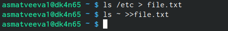

…

2. Выведите имена всех файлов из file.txt, имеющих расширение .conf, после чего запишите их в новый текстовой файл conf.txt

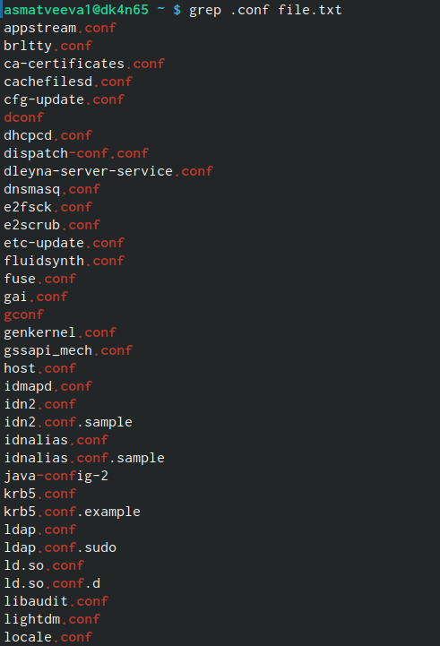

…

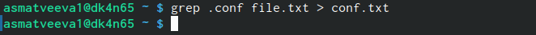

…

3. Определите, какие файлы в вашем домашнем каталоге имеют имена, начинавшиеся с символа c? Предложите несколько вариантов, как это сделать

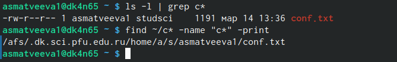

…

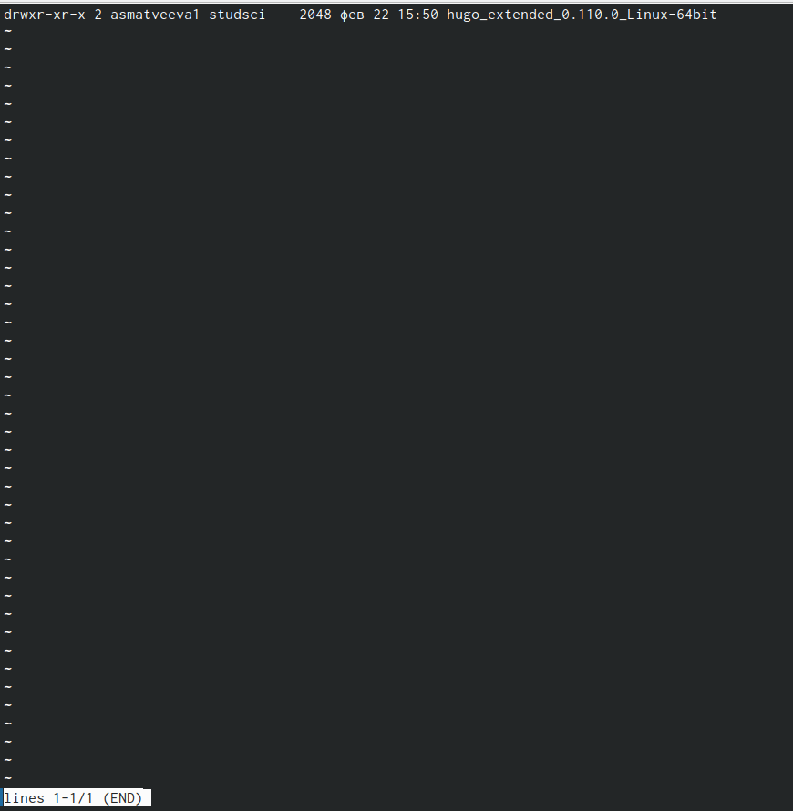

…

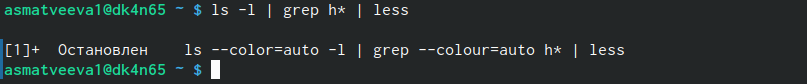

…

5. Запустите в фоновом режиме процесс, который будет записывать в файл ~/logfile файлы, имена которых начинаются с log.

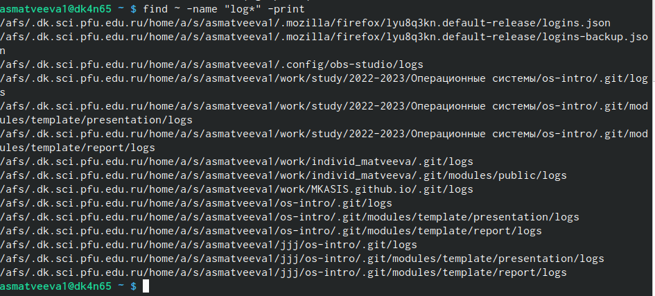

…

6. Удалите файл ~/logfile.

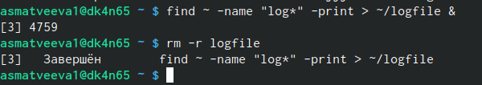

…

7. Запустите из консоли в фоновом режиме редактор gedit.

[figure not shown]

…

8. Определите идентификатор процесса gedit, используя команду ps, конвейер и фильтр grep. Как ещё можно определить идентификатор процесса?

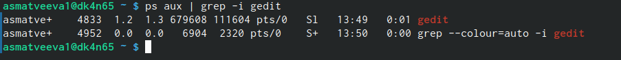

…

9. Прочтите справку (man) команды kill после чего используйте её для завершения процесса gedit

[figure not shown]

…

10. Выполните команды df и du, предварительно получив более подробную информацию об этих командах, с помощью команды man.

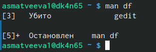

…

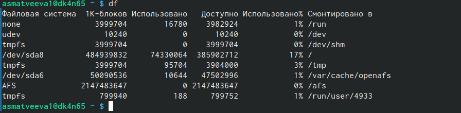

…

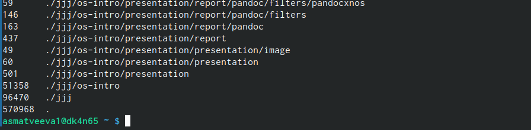

…

11. Воспользовавшись справкой команды find, выведите имена всех директорий, имеющихся в вашем домашнем каталоге

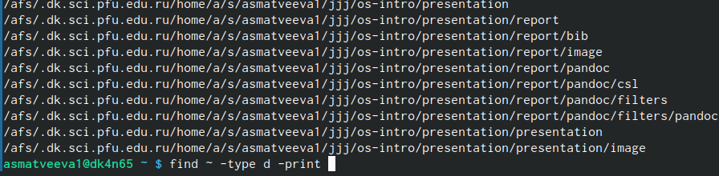

…

## Вывод

- мы молодцы